# Loan Dataset Presentation

## Brijrajsinh Gohil

## Investigation Overview

> The overall goals of this presentation is show the relationship between a variety of features that are present in our loan dataset, such as BorrowerAPR, BorrowerRate, ProsperRating (Alpha) and much more.

## Dataset Overview

> This is a Loan dataset provided by Prosper, it contains wide variety of features, both quantitative and qualitative. The dataset contains 113,066 rows and 81 columns, which are the features. The important features here are BorrowerAPR, BorrowerRate, LoanStatus, ProsperRating (Alpha) and Term length of the loan.

## Distribution of BorrowerAPR.

> From the distribution it can be observed that APR is distributed over a range from 0.05 to 0.45 approx. The highest value is around 0.2(approx).

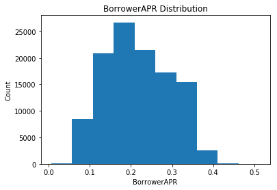

```python
# BorrowerAPR distribution
plt.hist(x = df_master['BorrowerAPR'])
plt.xlabel('BorrowerAPR')
plt.ylabel('Count')
plt.title('BorrowerAPR Distribution');
```

## Distribution of ProsperRating (Alpha).

> From the plob we can see that most of the ratings are of category 'C', while the least of 'AA'.

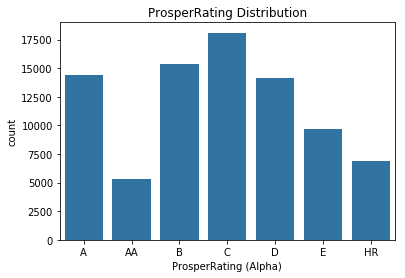

```python
# Prosper Rating (Alpha) plotting
sb.countplot(data = df_master, x = 'ProsperRating (Alpha)', color = base_color)
plt.title('ProsperRating Distribution');
```

## Correlation Plot between different features.

> From the plot below we can see a strong correlation between BorrowerAPR and BorrowerRate, which is of 0.990.

[figure not shown]

```python
numerical_vars = ['BorrowerAPR', 'DebtToIncomeRatio', 'StatedMonthlyIncome', 'LoanOriginalAmount', 'MonthlyLoanPayment', 'Term'
               , 'ProsperScore', 'Investors', 'BorrowerRate', 'ListingCategory (numeric)']

# Plotting correlation Plot
plt.figure(figsize=(10, 5))
sb.heatmap(df_master[numerical_vars].corr(), annot = True, fmt = '.3f', cmap = 'vlag_r', center = 0)
plt.title('Correlation - Numerical Variables')
plt.show();
```

## BorrowerAPR vs BorrowerRate

> They follow a linear relationship. They are strongly related to each other.

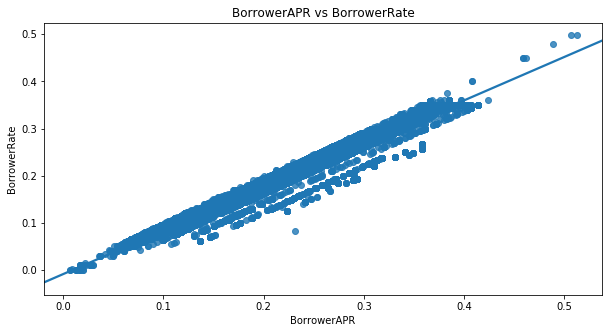

```python
# Plotting between BorrowerAPR and BorrowerRate
plt.figure(figsize=(10, 5))
sb.regplot(data = df_master, x = 'BorrowerAPR', y = 'BorrowerRate');
plt.title('BorrowerAPR vs BorrowerRate');
```

## ProsperRating (Alpha) vs BorrowerAPR

> From the figure it can be observed that they are negatively correlated, i.e. with increase in BorrowerAPR, there is a decrease in ProsperRating (Alpha) Category.

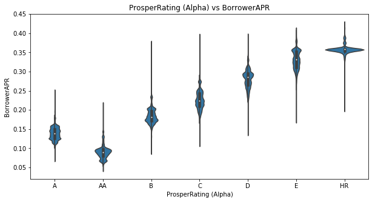

```python
# Plotting Violin Plot for ProsperRating and BorrowerAPR
plt.figure(figsize=(10, 5))
sb.violinplot(data = df_master, x = 'ProsperRating (Alpha)',y = 'BorrowerAPR',color = base_color);
plt.title('ProsperRating (Alpha) vs BorrowerAPR');
```

## ProsperRating (Alpha) vs BorrowerRate

> The same is observed with BorrowerRate, as it was previously observed with BorrowerAPR, i.e. negative correlation.

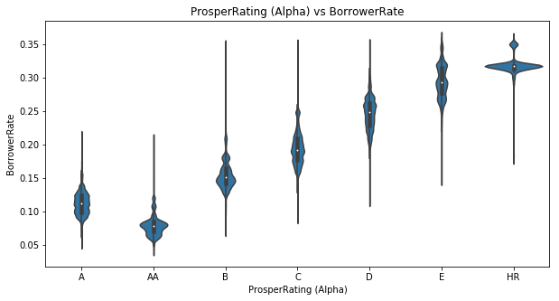

```python
plt.figure(figsize=(10, 5))
sb.violinplot(data = df_master, x = 'ProsperRating (Alpha)', y = 'BorrowerRate', color = base_color);
plt.title('ProsperRating (Alpha) vs BorrowerRate');
```

## BorrowerAPR vs ProsperRating (Alpha) vs ProsperScore

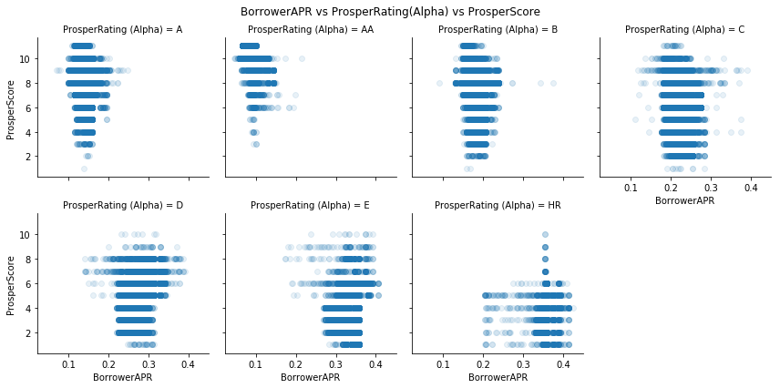

```python
g = sb.FacetGrid(data = df_master, col = 'ProsperRating (Alpha)', col_wrap = 4, size = 3)
g.map(plt.scatter, 'BorrowerAPR', 'ProsperScore', alpha = 0.1)
g.set_xlabels('BorrowerAPR')
g.set_ylabels('ProsperScore')
plt.subplots_adjust(top = 0.9)
g.fig.suptitle('BorrowerAPR vs ProsperRating(Alpha) vs ProsperScore')
plt.show();
```

```python
> > `jupyter nbconvert slide_deck_template.ipynb --to slides --post serve --template output_toggle`
```